# Timetk Demo

Matt Dancho

September 19, 2017

# timetk: What’s It Used For?

1. Coercing (converting) between time classes in R (e.g. between `tbl`, `xts`, `zoo`, `ts`)
2. Time series machine learning

# Load Libraries

```r
# devtools::install_github("business-science/timetk")
# devtools::install_github("business-science/tidyquant")
library(timetk)     # Functions working with time series
library(tidyquant)  # Loads tidyverse, financial pkgs, used to get data
```

# Data

Get data using `tidyquant`. The data comes from FRED: [Beer, Wine, and Distilled Alcoholic Beverages Sales](https://fred.stlouisfed.org/series/S4248SM144NCEN).

```r
# Beer, Wine, Distilled Alcoholic Beverages, in Millions USD
beer_sales_tbl <- tq_get("S4248SM144NCEN", get = "economic.data", from = "2010-01-01", to = "2016-12-31")

beer_sales_tbl
```

```
## # A tibble: 84 x 2
##          date price
##        <date> <int>
##  1 2010-01-01  6558
##  2 2010-02-01  7481
##  3 2010-03-01  9475
##  4 2010-04-01  9424
##  5 2010-05-01  9351
##  6 2010-06-01 10552
##  7 2010-07-01  9077
##  8 2010-08-01  9273
##  9 2010-09-01  9420
## 10 2010-10-01  9413
## # ... with 74 more rows
```

Visualize the data… nothing new here.

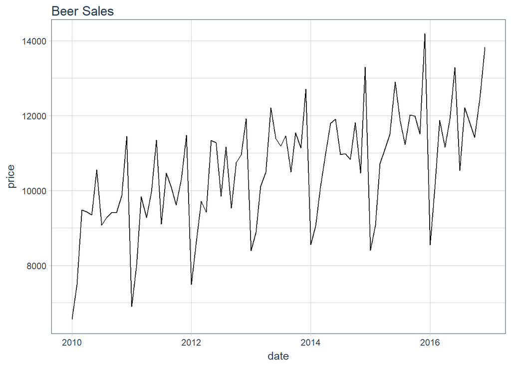

```r
# Plot Beer Sales
beer_sales_tbl %>%
    ggplot(aes(date, price)) +
    geom_line() +
    theme_tq() +
    labs(title = "Beer Sales")
```

# Part 1: Coercion

- **Problem**: Switching between various time classes in R is painful and inconsistent.
- **Solution**: `tk_tbl`, `tk_xts`, `tk_zoo`, `tk_ts`

### tk_xts

Convert to `xts` using `tk_xts()`

```r
# xts
beer_sales_xts <- tk_xts(beer_sales_tbl)

beer_sales_xts %>%
    head()
```

```
##            price
## 2010-01-01  6558
## 2010-02-01  7481
## 2010-03-01  9475
## 2010-04-01  9424
## 2010-05-01  9351
## 2010-06-01 10552
```

Can go from `xts` back to `tbl`.

```r
tk_tbl(beer_sales_xts, rename_index = "date")
```

```
## # A tibble: 84 x 2
##          date price
##        <date> <int>
##  1 2010-01-01  6558
##  2 2010-02-01  7481
##  3 2010-03-01  9475
##  4 2010-04-01  9424
##  5 2010-05-01  9351
##  6 2010-06-01 10552
##  7 2010-07-01  9077
##  8 2010-08-01  9273
##  9 2010-09-01  9420
## 10 2010-10-01  9413
## # ... with 74 more rows
```

### tk_ts

Convert to `ts` using `tk_ts()`.

```r
# ts
beer_sales_ts <- tk_ts(beer_sales_tbl, start = 2010, freq = 12)

beer_sales_ts
```

```
##        Jan   Feb   Mar   Apr   May   Jun   Jul   Aug   Sep   Oct   Nov
## 2010  6558  7481  9475  9424  9351 10552  9077  9273  9420  9413  9866
## 2011  6901  8014  9833  9281  9967 11344  9106 10468 10085  9612 10328
## 2012  7486  8641  9709  9423 11342 11274  9845 11163  9532 10754 10953
## 2013  8395  8888 10109 10493 12217 11385 11186 11462 10494 11541 11139
## 2014  8559  9061 10058 10979 11794 11906 10966 10981 10827 11815 10466
## 2015  8398  9061 10720 11105 11505 12903 11866 11223 12023 11986 11510
## 2016  8540 10158 11879 11155 11916 13291 10540 12212 11786 11424 12482
##        Dec
## 2010 11455
## 2011 11483
## 2012 11922
## 2013 12709
## 2014 13303
## 2015 14190
## 2016 13832
```

Can go back to `tbl`. Note that the date column is YEARMON class.

```r
tk_tbl(beer_sales_ts, rename_index = "date")
```

```
## # A tibble: 84 x 2
##             date price
##    <S3: yearmon> <int>
##  1      Jan 2010  6558
##  2      Feb 2010  7481
##  3      Mar 2010  9475
##  4      Apr 2010  9424
##  5      May 2010  9351
##  6      Jun 2010 10552
##  7      Jul 2010  9077
##  8      Aug 2010  9273
##  9      Sep 2010  9420
## 10      Oct 2010  9413
## # ... with 74 more rows
```

Can go back to tibble and with `timetk_idx = TRUE` to **return original DATE or DATETIME information**.

```r
# Check for timetk index.
has_timetk_idx(beer_sales_ts)
```

```
## [1] TRUE
```

```r
# If timetk_idx is present, can get original dates back
tk_tbl(beer_sales_ts, timetk_idx = TRUE, rename_index = "date")
```

```
## # A tibble: 84 x 2
##          date price
##        <date> <int>
##  1 2010-01-01  6558
##  2 2010-02-01  7481
##  3 2010-03-01  9475
##  4 2010-04-01  9424
##  5 2010-05-01  9351
##  6 2010-06-01 10552
##  7 2010-07-01  9077
##  8 2010-08-01  9273
##  9 2010-09-01  9420
## 10 2010-10-01  9413
## # ... with 74 more rows
```

# Part 2: Time Series Machine Learning

- **Key Insight**: The **time series signature** - time stamp information expanded into a feature set - is used to perform machine learning.
- **Objective**: We’ll predict the next 12 months of data for the time series.

### Step 0: Review data

```r
# Starting point
beer_sales_tbl
```

```
## # A tibble: 84 x 2
##          date price
##        <date> <int>
##  1 2010-01-01  6558
##  2 2010-02-01  7481
##  3 2010-03-01  9475
##  4 2010-04-01  9424
##  5 2010-05-01  9351
##  6 2010-06-01 10552
##  7 2010-07-01  9077
##  8 2010-08-01  9273
##  9 2010-09-01  9420
## 10 2010-10-01  9413
## # ... with 74 more rows
```

### Step 1: Augment Time Series Signature

The `tk_augment_timeseries_signature()` function expands out the timestamp information into a machine learning feature set. Adds 28 columns of time series information.

```r
# Augment (adds data frame columns)
beer_sales_tbl_aug <- beer_sales_tbl %>%
    tk_augment_timeseries_signature()

beer_sales_tbl_aug
```

```
## # A tibble: 84 x 30
##          date price  index.num    diff  year year.iso  half quarter month
##        <date> <int>      <int>   <int> <int>    <int> <int>   <int> <int>
##  1 2010-01-01  6558 1262304000      NA  2010     2009     1       1     1
##  2 2010-02-01  7481 1264982400 2678400  2010     2010     1       1     2
##  3 2010-03-01  9475 1267401600 2419200  2010     2010     1       1     3
##  4 2010-04-01  9424 1270080000 2678400  2010     2010     1       2     4
##  5 2010-05-01  9351 1272672000 2592000  2010     2010     1       2     5
##  6 2010-06-01 10552 1275350400 2678400  2010     2010     1       2     6
##  7 2010-07-01  9077 1277942400 2592000  2010     2010     2       3     7
##  8 2010-08-01  9273 1280620800 2678400  2010     2010     2       3     8
##  9 2010-09-01  9420 1283299200 2678400  2010     2010     2       3     9
## 10 2010-10-01  9413 1285891200 2592000  2010     2010     2       4    10
## # ... with 74 more rows, and 21 more variables: month.xts <int>,
## #   month.lbl <ord>, day <int>, hour <int>, minute <int>, second <int>,
## #   hour12 <int>, am.pm <int>, wday <int>, wday.xts <int>, wday.lbl <ord>,
## #   mday <int>, qday <int>, yday <int>, mweek <int>, week <int>,
## #   week.iso <int>, week2 <int>, week3 <int>, week4 <int>, mday7 <int>
```

### Step 2: Model

Apply any regression model to the data. We’ll use `lm()`.

```r
# linear regression model used, but can use any model
fit_lm <- lm(price ~ ., data = select(beer_sales_tbl_aug, -c(date, diff)))

summary(fit_lm)
```

```
##
## Call:
## lm(formula = price ~ ., data = select(beer_sales_tbl_aug, -c(date,
##     diff)))
##
## Residuals:
##    Min     1Q Median     3Q    Max
## -447.3 -145.4  -18.2  169.8  421.4
##
## Coefficients: (16 not defined because of singularities)
##                Estimate Std. Error t value Pr(>|t|)
## (Intercept)   3.660e+08  1.245e+08   2.940 0.004738 **
## index.num     5.900e-03  2.003e-03   2.946 0.004661 **
## year         -1.974e+05  6.221e+04  -3.173 0.002434 **
## year.iso      1.159e+04  6.546e+03   1.770 0.082006 .
## half         -2.132e+03  6.107e+02  -3.491 0.000935 ***
## quarter      -1.239e+04  2.190e+04  -0.566 0.573919
## month        -3.910e+03  7.355e+03  -0.532 0.597058
## month.xts            NA         NA      NA       NA
## month.lbl.L          NA         NA      NA       NA
## month.lbl.Q  -1.643e+03  2.069e+02  -7.942 8.59e-11 ***
## month.lbl.C   8.368e+02  5.139e+02   1.628 0.108949
## month.lbl^4   6.452e+02  1.344e+02   4.801 1.18e-05 ***
## month.lbl^5   7.563e+02  4.241e+02   1.783 0.079852 .
## month.lbl^6   3.206e+02  1.609e+02   1.992 0.051135 .
## month.lbl^7  -3.537e+02  1.867e+02  -1.894 0.063263 .
## month.lbl^8   3.687e+02  3.217e+02   1.146 0.256510
## month.lbl^9          NA         NA      NA       NA
## month.lbl^10  6.339e+02  2.240e+02   2.830 0.006414 **
## month.lbl^11         NA         NA      NA       NA
## day                  NA         NA      NA       NA
## hour                 NA         NA      NA       NA
## minute               NA         NA      NA       NA
## second               NA         NA      NA       NA
## hour12               NA         NA      NA       NA
## am.pm                NA         NA      NA       NA
## wday         -8.264e+01  1.898e+01  -4.353 5.63e-05 ***
## wday.xts             NA         NA      NA       NA
## wday.lbl.L           NA         NA      NA       NA
## wday.lbl.Q   -7.109e+02  1.093e+02  -6.503 2.13e-08 ***
## wday.lbl.C    2.355e+02  1.336e+02   1.763 0.083273 .
## wday.lbl^4    8.033e+01  1.133e+02   0.709 0.481281
## wday.lbl^5    6.480e+01  8.029e+01   0.807 0.422951
## wday.lbl^6    2.276e+01  8.200e+01   0.278 0.782319
## mday                 NA         NA      NA       NA
## qday         -1.362e+02  2.418e+02  -0.563 0.575326
## yday         -2.356e+02  1.416e+02  -1.664 0.101627
## mweek        -1.670e+02  1.477e+02  -1.131 0.262923
## week         -1.764e+02  1.890e+02  -0.933 0.354618
## week.iso      2.315e+02  1.256e+02   1.842 0.070613 .
## week2        -1.235e+02  1.547e+02  -0.798 0.428283
## week3                NA         NA      NA       NA
## week4                NA         NA      NA       NA
## mday7                NA         NA      NA       NA
## ---
## Signif. codes:  0 '***' 0.001 '**' 0.01 '*' 0.05 '.' 0.1 ' ' 1
##
## Residual standard error: 260.4 on 57 degrees of freedom
## Multiple R-squared:  0.9798, Adjusted R-squared:  0.9706
## F-statistic: 106.4 on 26 and 57 DF,  p-value: < 2.2e-16
```

### Step 3: Build Future (New) Data

Use `tk_index()` to extract the index.

```r
# Retrieves the timestamp information
beer_sales_idx <- beer_sales_tbl %>%
    tk_index()

tail(beer_sales_idx)
```

```
## [1] "2016-07-01" "2016-08-01" "2016-09-01" "2016-10-01" "2016-11-01"
## [6] "2016-12-01"
```

Make a future index from the existing index.

```r
# Make future index
future_idx <- beer_sales_idx %>%
    tk_make_future_timeseries(n_future = 12)

future_idx
```

```
##  [1] "2017-01-01" "2017-02-01" "2017-03-01" "2017-04-01" "2017-05-01"
##  [6] "2017-06-01" "2017-07-01" "2017-08-01" "2017-09-01" "2017-10-01"
## [11] "2017-11-01" "2017-12-01"
```

From the future index, use `tk_get_timeseries_signature()` to turn index into time signature data frame.

```r
new_data_tbl <- future_idx %>%
    tk_get_timeseries_signature()

new_data_tbl
```

```
## # A tibble: 12 x 29
##         index  index.num    diff  year year.iso  half quarter month
##        <date>      <int>   <int> <int>    <int> <int>   <int> <int>
##  1 2017-01-01 1483228800      NA  2017     2016     1       1     1
##  2 2017-02-01 1485907200 2678400  2017     2017     1       1     2
##  3 2017-03-01 1488326400 2419200  2017     2017     1       1     3
##  4 2017-04-01 1491004800 2678400  2017     2017     1       2     4
##  5 2017-05-01 1493596800 2592000  2017     2017     1       2     5
##  6 2017-06-01 1496275200 2678400  2017     2017     1       2     6
##  7 2017-07-01 1498867200 2592000  2017     2017     2       3     7
##  8 2017-08-01 1501545600 2678400  2017     2017     2       3     8
##  9 2017-09-01 1504224000 2678400  2017     2017     2       3     9
## 10 2017-10-01 1506816000 2592000  2017     2017     2       4    10
## 11 2017-11-01 1509494400 2678400  2017     2017     2       4    11
## 12 2017-12-01 1512086400 2592000  2017     2017     2       4    12
## # ... with 21 more variables: month.xts <int>, month.lbl <ord>, day <int>,
## #   hour <int>, minute <int>, second <int>, hour12 <int>, am.pm <int>,
## #   wday <int>, wday.xts <int>, wday.lbl <ord>, mday <int>, qday <int>,
## #   yday <int>, mweek <int>, week <int>, week.iso <int>, week2 <int>,
## #   week3 <int>, week4 <int>, mday7 <int>
```

### Step 4: Predict the New Data

Use the `predict()` function for your regression model.

```r
# Make predictions
pred <- predict(fit_lm, newdata = select(new_data_tbl, -c(index, diff)))

predictions_tbl <- tibble(
    date  = future_idx,
    value = pred
    )

predictions_tbl
```

```
## # A tibble: 12 x 2
##          date     value
##        <date>     <dbl>
##  1 2017-01-01  9509.122
##  2 2017-02-01 10909.189
##  3 2017-03-01 12281.835
##  4 2017-04-01 11378.678
##  5 2017-05-01 13080.710
##  6 2017-06-01 13583.471
##  7 2017-07-01 11529.085
##  8 2017-08-01 12984.939
##  9 2017-09-01 11859.998
## 10 2017-10-01 12331.419
## 11 2017-11-01 13047.033
## 12 2017-12-01 13940.003
```

Visualize our forecast.

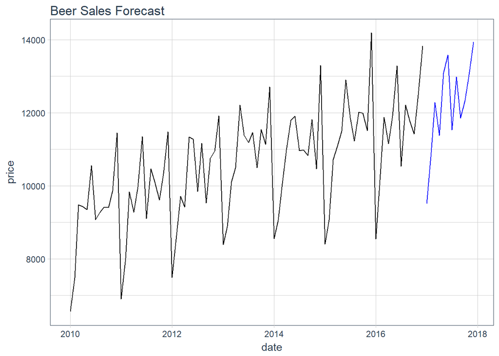

```r
# Plot Beer Sales Forecast
beer_sales_tbl %>%
    ggplot(aes(x = date, y = price)) +
    geom_line() +
    geom_line(aes(y = value), color = "blue", data = predictions_tbl) +
    theme_tq() +
    labs(title = "Beer Sales Forecast")
```

# More Information

- Check out our [GitHub Page](https://github.com/business-science/timetk)
- Check out our [timetk documentation](https://business-science.github.io/timetk/)
- Check out our [Business Science Insights Blog](http://www.business-science.io/blog/index.html)